# Praca domowa 2

Zuzanna Zalewska

## Dane

Dane wykorzystane w Pracy domowej 2 opisują wycenę nieruchmości. Każda obserwacja jest pewną nieruchmością, która posiada informacje takie jak powierzchnia, liczba pokoi, liczba łazienek i wiele więcj. Opis wszystkich kolumn w pliku `README.md`.

## Zadanie 1

Jak wygląda rozkład ceny nieruchomości w poszczególnych kodach pocztowych na przestrzeni lat? Rozważamy kody pocztowe, które mają więcej niż 280 posiadłości.

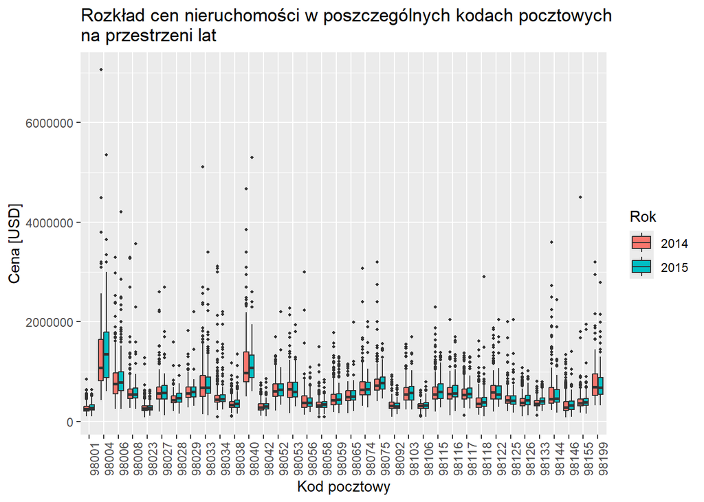

```r
df %>%
  group_by(zipcode) %>%
  filter(length(zipcode)>280) %>%
  ungroup() %>%
  ggplot(aes(y=price,x=as.factor(zipcode),fill=substr(date,0,4))) +
  geom_boxplot(outlier.size = 0.75)+
  labs(title="Rozkład cen nieruchomości w poszczególnych kodach pocztowych\nna przestrzeni lat",
       x="Kod pocztowy",
       y="Cena [USD]",
       fill="Rok")+
  theme(axis.text.x = element_text(angle = 90, hjust = 1))
```

**Komentarz: W większości kodów pocztowych mediana ceny wzrasta na przestrzeni roku.**

## Zadanie 2

Czy jest różnica w rozkładzie ceny nierchomości od powierzchni mieszkalnej uwzględniając podział na nieruchomości z piwnicą i bez?

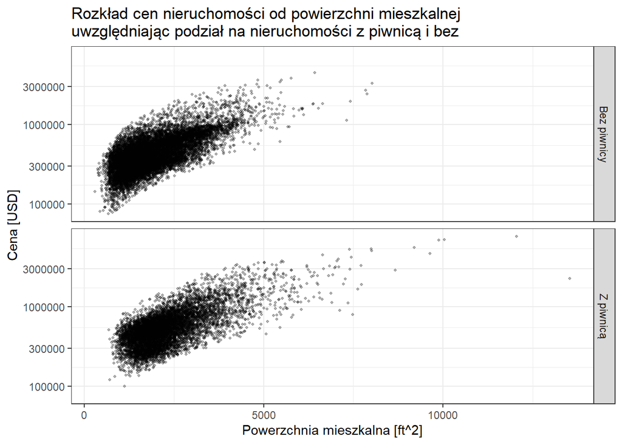

```r
df %>%
  mutate(is_basement=ifelse(sqft_basement==0,"Bez piwnicy","Z piwnicą")) %>%
  ggplot(aes(y=price,x=sqft_living))+
  geom_point(size=0.75,alpha=0.3)+
  facet_grid(vars(is_basement))+
  theme_bw()+
  scale_y_log10()+
  labs(title="Rozkład cen nieruchomości od powierzchni mieszkalnej\nuwzględniając podział na nieruchomości z piwnicą i bez",
       y="Cena [USD]",
       x="Powerzchnia mieszkalna [ft^2]")
```

**Komentarz: Można zauważyć, że nieruchomości bez piwnicy mają trochę niższą cenę.**

## Zadanie 3

Jaka jest zależność pomiędzy jakością wykończenia nieruchomości a liczbą pięter?

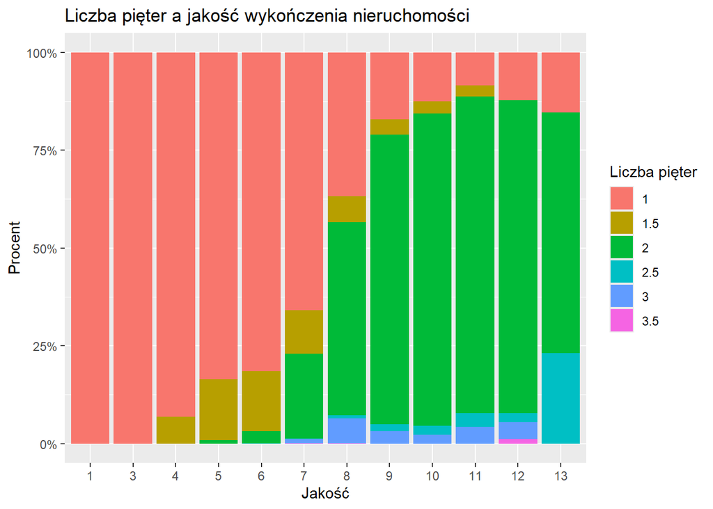

```r
df %>%
  group_by(grade,floors) %>%
  summarise(n=n()) %>%
  ungroup() %>%
  ggplot(aes(x=as.factor(grade),y=n,fill=as.factor(floors))) +
  geom_bar(position="fill", stat="identity")+
  labs(title="Liczba pięter a jakość wykończenia nieruchomości",
       x="Jakość",
       fill="Liczba pięter",
       y="Procent")+
  scale_y_continuous(labels =percent)
```

**Komentarz: Zauważalna jest zależność, że wraz ze wzrostem liczby pięter wzrasta jakość wykończenia mieszkania.**

## Zadanie 4

Jaka jest zależność między powierzchnią mieszkalną nieruchomości a powierzchnią gruntu w podziale na liczbę sypialni?

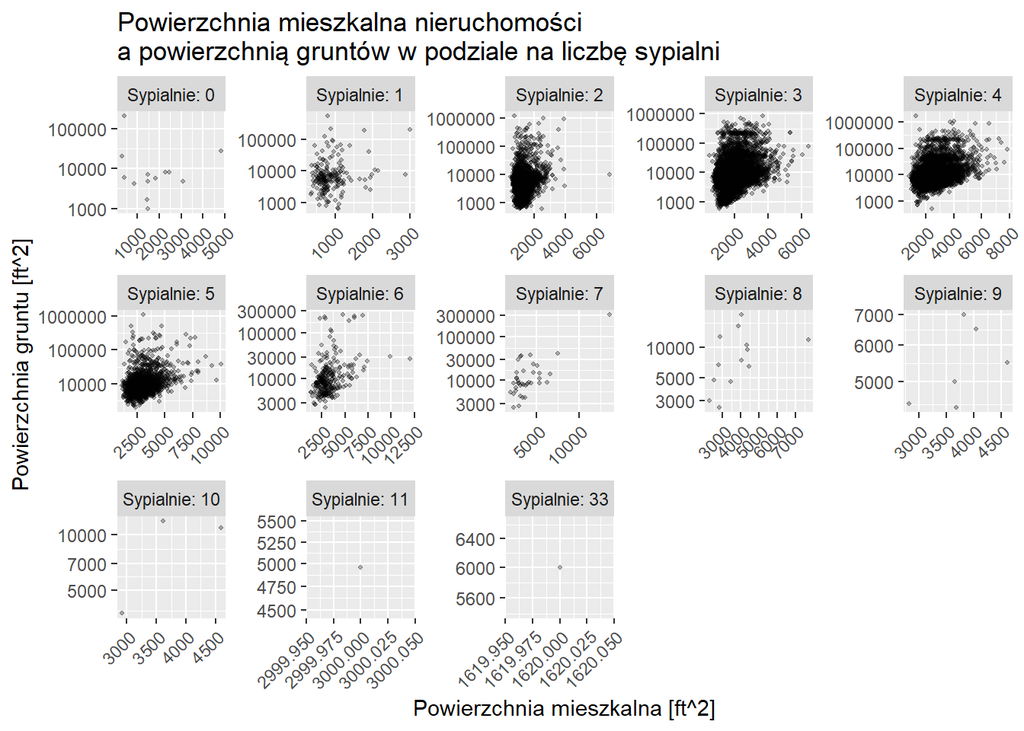

```r
labels=c("0"="Sypialnie: 0","1"="Sypialnie: 1","2"="Sypialnie: 2","3"="Sypialnie: 3","4"="Sypialnie: 4","5"="Sypialnie: 5","6"="Sypialnie: 6",
         "7"="Sypialnie: 7","8"="Sypialnie: 8","9"="Sypialnie: 9","10"="Sypialnie: 10","11"="Sypialnie: 11","33"="Sypialnie: 33")
df %>%
  ggplot(aes(x=sqft_living,y=sqft_lot)) +
  geom_point(size=0.8,alpha=0.3)+
  theme(axis.text.x = element_text(angle = 45, hjust = 1))+
  facet_wrap(vars(bedrooms),scales="free",labeller = as_labeller(labels),ncol=5)+
  labs(title="Powierzchnia mieszkalna nieruchomości\na powierzchnią gruntów w podziale na liczbę sypialni",
       x="Powierzchnia mieszkalna [ft^2]",
       y="Powierzchnia gruntu [ft^2]")+
  scale_y_log10()
```

**Komentarz: Powierzchnia mieszkalna wzrasta wraz ze wzrostem powierzchni gruntów w większości przypadków. Im więcej sypialni tym większa powierzchnia mieszkalna.**

## Zadanie 5

Rozważmy tylko nieruchomości, które miały remont. W której dekadzie było najwięcej przeprowadzonych remontów? Czy w poszczególnych dekadach jest porównywalny procent nieruchmości dla każdej wartości miary jakości i wykończenia nieruchomości?

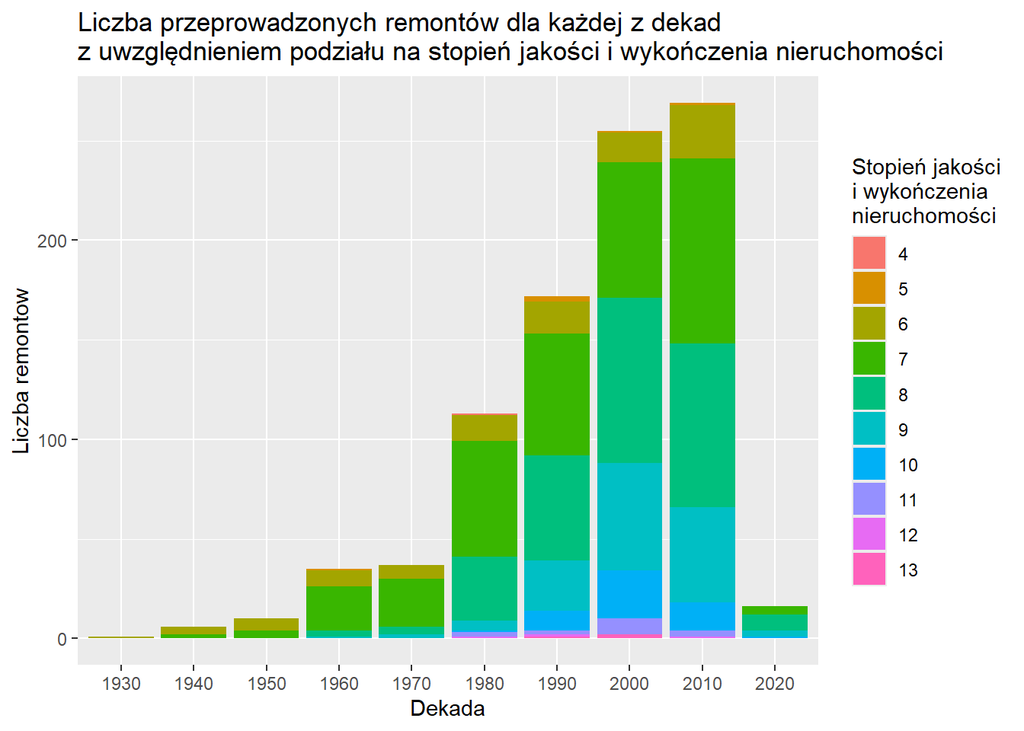

```r
df %>%
  filter(yr_renovated!=0) %>%
  mutate(decade=round(yr_renovated,-1)) %>%
  group_by(decade,grade) %>%
  summarise(cnt=n()) %>%
  ungroup() %>%
  ggplot(aes(x=as.factor(decade),y=cnt,fill=as.factor(grade))) +
  geom_bar(position="stack", stat="identity")+
  labs(title="Liczba przeprowadzonych remontów dla każdej z dekad\nz uwzględnieniem podziału na stopień jakości i wykończenia nieruchomości",
       x='Dekada',
       y='Liczba remontow',
       fill='Stopień jakości\ni wykończenia\nnieruchomości')
```

## Zadanie 6

Jak prezentuje się wartość minimalna, średnia i maksymalna ceny nieruchmości w podziele na rok budowy nieruchomości.

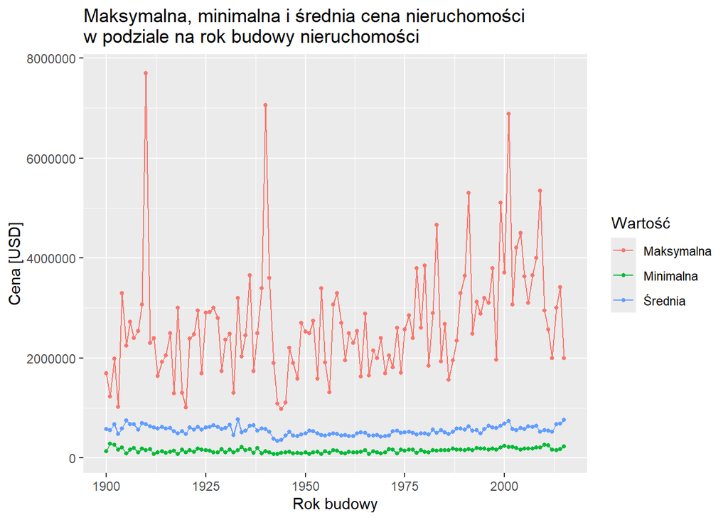

```r
df %>%
  group_by(yr_built) %>%
  summarise(min=min(price),max=max(price),mean=mean(price)) %>%
  ungroup() %>%
  ggplot(aes(x=yr_built)) +
  geom_line(aes(y = mean, color = "Średnia")) +
  geom_line(aes(y = min, color = "Minimalna")) +
  geom_line(aes(y = max, color = "Maksymalna")) +
  geom_point(aes(y=min,color="Minimalna"),size=1)+
  geom_point(aes(y=max,color="Maksymalna"),size=1)+
  geom_point(aes(y=mean,color="Średnia"),size=1)+
  labs(title="Maksymalna, minimalna i średnia cena nieruchomości\nw podziale na rok budowy nieruchomości",
       x="Rok budowy",
       y="Cena [USD]",
       color="Wartość")
```

**Komentarz: Minimalne oraz średnie wartości cen nieruchomości pozostają na mniej więcej stałym poziomie przez kolejne lata. Zaś maksymalne wartości nieruchomości mogą się znacznie różnić na przestrzeni nawet kolejnych kilku lat.**